# Assignment 11

2025-05-20

### Downloading packages and data

```r
suppressPackageStartupMessages({
  library(BiocParallel)
  library(bsseq)
  library(DMRcate)
  library(rGREAT)
  library(knitr)
  library(pheatmap)
  library(kableExtra)
})
dmrs <- readRDS("dmr.rds")
bs <- readRDS("ESC_astrocytes_BSseq.rds")
```

### Top 5 DMR regions located on chr1

```r
dmrs_chr1 <- dmrs[seqnames(dmrs) == "chr1"]

top5_chr1 <- dmrs_chr1[order(abs(dmrs_chr1$meandiff), decreasing = TRUE)][1:5]
top5_chr1
```

```
## GRanges object with 5 ranges and 8 metadata columns:
##       seqnames              ranges strand |   no.cpgs min_smoothed_fdr
##          <Rle>           <IRanges>  <Rle> | <integer>        <numeric>
##   [1]     chr1 207818394-207818642      * |        19     2.24056e-271
##   [2]     chr1 240160779-240161545      * |        47      0.00000e+00
##   [3]     chr1 230993054-230993133      * |         6      1.82406e-77
##   [4]     chr1 207842898-207842965      * |         7      2.46074e-85
##   [5]     chr1   40598617-40598663      * |         5      1.35401e-59
##           Stouffer       HMFDR       Fisher   maxdiff  meandiff
##          <numeric>   <numeric>    <numeric> <numeric> <numeric>
##   [1] 3.26399e-130 1.86056e-10 1.54617e-122 -11.56201  -9.18854
##   [2] 6.83910e-304 4.95791e-10 3.05917e-284 -11.49759  -8.85801
##   [3]  1.43110e-40 5.35879e-09  2.64037e-38  -9.78203  -8.84035
##   [4]  1.36786e-44 3.99552e-09  3.24805e-42 -10.06336  -8.48854
##   [5]  2.22903e-32 5.63162e-09  1.77821e-30  -9.78331  -8.46054
##       overlapping.genes
##             <character>
##   [1]      CR1L, CD46P1
##   [2]              <NA>
##   [3]          C1orf198
##   [4]              CR1L
##   [5]      RP11-115D7.3
##   -------
##   seqinfo: 23 sequences from an unspecified genome; no seqlengths
```

```r
bs <- bs[rowSums(assay(bs,"Cov") > 0) == ncol(bs), ]
bs <- BSmooth(bs, BPPARAM = MulticoreParam(4))

meth_top5 <- getMeth(bs, regions = top5_chr1, what = "perRegion")
rownames(meth_top5) <- paste0("DMR_", seq_len(nrow(meth_top5)))
meth_top5
```

```
##       astrocytes_ENCFF001TPN astrocytes_ENCFF001TPP ESC_ENCFF001TMC
## DMR_1           1.315275e-01           0.0472132719       0.9259136
## DMR_2           5.327416e-07           0.0004595368       0.9976894
## DMR_3           1.329234e-01           0.0800837219       0.6437581
## DMR_4           4.061215e-01           0.1439837867       0.8467105
## DMR_5           2.112459e-02           0.0271840998       0.9723071
##       ESC_ENCFF001TMD
## DMR_1       0.9097451
## DMR_2       0.9402947
## DMR_3       0.7371649
## DMR_4       0.8564158
## DMR_5       0.9556082
```

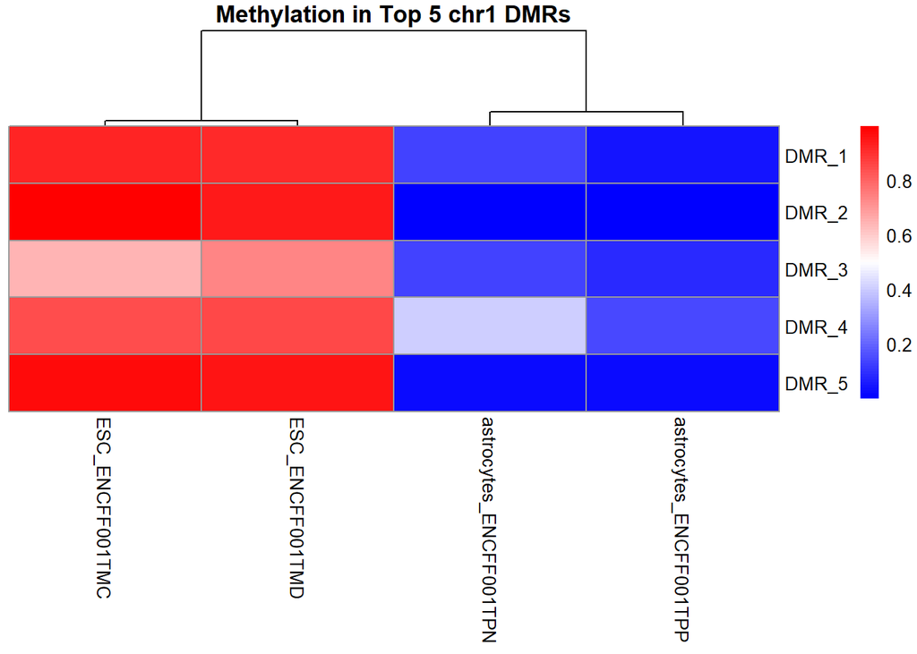

```r
pheatmap(meth_top5, cluster_rows = FALSE, cluster_cols = TRUE, main = "Methylation in Top 5 chr1 DMRs", color = colorRampPalette(c("blue", "white", "red"))(100))
```

### Enrichment analysis

```r
job <- submitGreatJob(dmrs, species = "hg19")
enrich_tables <- getEnrichmentTables(job, download_by = "tsv")
go_bp <- enrich_tables$`GO Biological Process`

top5_rows <- head(go_bp, 5)
gene_table <- data.frame(Gene = character(),
                         GO_Term = character(),
                         FoldEnrichment = numeric(),
                         FDR = numeric(),
                         stringsAsFactors = FALSE)

for (i in 1:nrow(top5_rows)) {
  genes <- unlist(strsplit(top5_rows$Genes[i], ","))
  for (gene in genes) {
    gene_table <- rbind(gene_table, data.frame(
      Gene = gene,
      GO_Term = top5_rows$Desc[i],
      FoldEnrichment = top5_rows$RegionFoldEnrich[i],
      FDR = top5_rows$BinomFdrQ[i]
    ))
  }
}

knitr::kable(gene_table, caption = "Genes from Top 5 Enriched GO Biological Processes")
```

Genes from Top 5 Enriched GO Biological Processes

| Gene | GO_Term | FoldEnrichment | FDR |
| --- | --- | --- | --- |
| NCOR2 | regulation of cellular ketone metabolic process by regulation of transcription from RNA polymerase II promoter | 30.35778 | 0 |
| PPARA | regulation of cellular ketone metabolic process by regulation of transcription from RNA polymerase II promoter | 30.35778 | 0 |
| CDX1 | regulation of somitogenesis | 12.99773 | 0 |
| DLL1 | regulation of somitogenesis | 12.99773 | 0 |
| DMRT2 | regulation of somitogenesis | 12.99773 | 0 |
| LFNG | regulation of somitogenesis | 12.99773 | 0 |
| NKD1 | regulation of somitogenesis | 12.99773 | 0 |
| NOTCH1 | regulation of somitogenesis | 12.99773 | 0 |
| NRARP | regulation of somitogenesis | 12.99773 | 0 |
| ADAMTSL2 | lobar bronchus development | 24.78657 | 0 |
| HOXA5 | lobar bronchus development | 24.78657 | 0 |
| WNT7B | lobar bronchus development | 24.78657 | 0 |
| WNT7B | outer medullary collecting duct development | 37.52972 | 0 |
| WNT7B | establishment or maintenance of polarity of embryonic epithelium | 37.52972 | 0 |

**Associated Genes for Each Term:**

1. **Regulation of cellular ketone metabolic process…**  
   → `NCOR2, PPARA`
2. **Regulation of somitogenesis**  
   → `CDX1, DLL1, DMRT2, LFNG, NKD1, NOTCH1, NRARP`
3. **Lobar bronchus development**  
   → `ADAMTSL2, HOXA5, WNT7B`
4. **Outer medullary collecting duct development**  
   → `WNT7B`
5. **Establishment or maintenance of polarity of embryonic epithelium**  
   → `WNT7B`

### Interpretation of Enrichment Analysis

We used the `rGREAT` package to perform a functional enrichment analysis on the differentially methylated regions (DMRs) identified between embryonic stem cells (ESCs) and astrocytes.

This analysis tests whether our DMRs are located near genes associated with specific Gene Ontology (GO) Biological Processes **more often than would be expected by chance**, compared to the entire genome. The goal is to determine if these DMRs are functionally biased toward certain biological functions.

The top enriched GO terms included: - **Regulation of somitogenesis** - **Lobar bronchus development** - **Establishment or maintenance of polarity of embryonic epithelium**

All five top terms had very high region fold enrichment (e.g. up to 37x) and false discovery rates (FDR) of 0, indicating strong statistical significance. These terms are consistent with gene regulation events during **early development and differentiation**, supporting the biological relevance of the methylation changes observed between pluripotent and differentiated cell types.

Notably, genes such as **WNT7B**, **NOTCH1**, and **PPARA** were implicated, aligning with known roles in developmental signaling and cell fate determination.